# 628hw7

Ruohan wang

4/26/2022

1a

Marginal Models for correlated outcomes. since in Hw5, it is a conditional model.

If it is a conditional model, one should use a GLMM model. So it is not suitable for

fitting a marginal model via GEE. Also if the dataset becomes larger, will fit more

GEE requirement that dataset be large.

1b

compared the two formula of Naïve or ‘model-based’ variance of β estimator and

Robust or ‘Empirical’ (Sandwich) variance of β estimato in slides 13, it implies

two foumulas will get the same output by the conoutation of matrix.

1c

Advantages of implementing a GEE model over a GLMM model:

1.Marginal’: for longitudinal data, mean response is conditional only on covariates at that time and NOT on other responses or covariates at other time points and NOT on random effects.

2.Marginal models do not require the joint distributional assumptions for the vector of responses

3. Marginal models SEPARATELY model the mean response and the covariance (within-subject or within-cluster association) among repeated responses (1,2,3 from slides)

4.The point estimates, on the other hand, are the same as with the models for independent data. Sandwich variance estimation, which sandwiches the expected (A matrix or bread) and observed (B matrix or meat) information to produce robust error estimation, is also used. Even for independent data, the sandwich is a powerful estimator, producing heteroscedasticity consistent standard error estimates.

```r
#2a
setwd("~/Downloads")
df = read.csv("datasmoking.csv")
df=na.omit(df)
df$monthsquared=(df$month)^2
#install.packages("geepack")
library(geepack)
# m1.ind <- geeglm(quit ~ racew*month+racew*monthsquared+control*month +control*monthsquared + noshow*month +noshow*monthsquared+ discussion*month +discussion*monthsquared+ socsup*month +socsup*monthsquared, data=df, family=binomial(link="logit"), id=id, corstr = "independence", std.err="san.se")
# summary(m1.ind)
#


m1.ind <- geeglm(quit ~ racew*month + racew*monthsquared + noshow*month + noshow*monthsquared + discussion*month +discussion*monthsquared + socsup*month + socsup*monthsquared, data=df, family=binomial(link="logit"),
                 id=id, corstr = "independence", std.err="san.se")
summary(m1.ind)
```

```
##
## Call:
## geeglm(formula = quit ~ racew * month + racew * monthsquared +
##     noshow * month + noshow * monthsquared + discussion * month +
##     discussion * monthsquared + socsup * month + socsup * monthsquared,
##     family = binomial(link = "logit"), data = df, id = id, corstr = "independence",
##     std.err = "san.se")
##
##  Coefficients:
##                           Estimate    Std.err   Wald Pr(>|W|)
## (Intercept)             -1.7125462  0.2776416 38.047 6.91e-10 ***
## racew                    0.0186560  0.2508195  0.006  0.94071
## month                   -0.0742988  0.0478993  2.406  0.12087
## monthsquared             0.0032469  0.0017806  3.325  0.06822 .
## noshow                   0.6789085  0.3128452  4.709  0.03000 *
## discussion               0.9810633  0.3543435  7.666  0.00563 **
## socsup                   1.5787381  0.3323067 22.571 2.03e-06 ***
## racew:month              0.1091607  0.0464536  5.522  0.01878 *
## racew:monthsquared      -0.0036835  0.0017781  4.292  0.03830 *
## month:noshow            -0.0365467  0.0562378  0.422  0.51578
## monthsquared:noshow      0.0003315  0.0021179  0.025  0.87561
## month:discussion        -0.1015633  0.0694169  2.141  0.14344
## monthsquared:discussion  0.0032296  0.0026415  1.495  0.22148
## month:socsup            -0.1290774  0.0625729  4.255  0.03913 *
## monthsquared:socsup      0.0035631  0.0023673  2.266  0.13228
## ---
## Signif. codes:  0 '***' 0.001 '**' 0.01 '*' 0.05 '.' 0.1 ' ' 1
##
## Correlation structure = independence
## Estimated Scale Parameters:
##
##             Estimate Std.err
## (Intercept)    1.003 0.09725
## Number of clusters:   489  Maximum cluster size: 4
```

Equation for this marginal model:

Logit(pr(yij=1/pr(yij=0 )))

=beta1+beta2*racew + beta3* month + beta4 * monthsquared +beta5* noshow + beta6*discussion +

beta7* socsup +beta8*racew:month + beta9*racew:monthsquared+ beta10*month:noshow +beta11*monthsquared:noshow+ + beta12*month:discussion+ beta13*monthsquared:discussion + beta14*month:socsup +beta15*monthsquared:socsup

####2b

Important assumption in a marginal model: g(μij)=g{E(Yij|Xij)}

Independent Yi AND no assumed distributional assumption, the independence assumption for R.

For longitudinal data, mean response is conditional only on covariates at that time and NOT

on other responses or covariates at other time points and NOT on random effects.

Working Covariance matrix of Yi conditional on Xi is Vi = Ai1/2 Ri Ai1/2

#####2c

Canonical Link function for mean response, μij: g(μij) = log(μij/(1-μij)

```r
#2d (i)
#Run Generalized Wald test to examine whether we need "TXSWK" by using the best working Vi from m1.ar1
# m1.toep <- geeglm(quit ~ racew*month + racew*monthsquared + noshow*month + noshow*monthsquared + discussion*month +discussion*monthsquared + socsup*month + socsup*monthsquared, data=df, family=binomial(link="logit"),
#                  id=id, corstr = "userdefined", std.err="san.se")
#summary(userdefined)

m1.reduced <- geeglm(quit ~ racew+month + racew+monthsquared + noshow*month + noshow*monthsquared + discussion*month +discussion*monthsquared + socsup*month + socsup*monthsquared, data=df, family=binomial(link="logit"),
                 id=id, corstr = "independence", std.err="san.se")
summary(m1.reduced)
```

```
##
## Call:
## geeglm(formula = quit ~ racew + month + racew + monthsquared +
##     noshow * month + noshow * monthsquared + discussion * month +
##     discussion * monthsquared + socsup * month + socsup * monthsquared,
##     family = binomial(link = "logit"), data = df, id = id, corstr = "independence",
##     std.err = "san.se")
##
##  Coefficients:
##                          Estimate   Std.err  Wald Pr(>|W|)
## (Intercept)             -1.847588  0.278963 43.86  3.5e-11 ***
## racew                    0.426032  0.201602  4.47   0.0346 *
## month                   -0.035726  0.044686  0.64   0.4240
## monthsquared             0.001937  0.001677  1.33   0.2480
## noshow                   0.661856  0.314920  4.42   0.0356 *
## discussion               1.090125  0.358178  9.26   0.0023 **
## socsup                   1.649462  0.334886 24.26  8.4e-07 ***
## month:noshow            -0.033018  0.055981  0.35   0.5553
## monthsquared:noshow      0.000211  0.002102  0.01   0.9200
## month:discussion        -0.132074  0.068809  3.68   0.0549 .
## monthsquared:discussion  0.004260  0.002628  2.63   0.1050
## month:socsup            -0.149088  0.061832  5.81   0.0159 *
## monthsquared:socsup      0.004236  0.002355  3.24   0.0720 .
## ---
## Signif. codes:  0 '***' 0.001 '**' 0.01 '*' 0.05 '.' 0.1 ' ' 1
##
## Correlation structure = independence
## Estimated Scale Parameters:
##
##             Estimate Std.err
## (Intercept)    0.999  0.0881
## Number of clusters:   489  Maximum cluster size: 4
```

```r
anova(m1.ind,m1.reduced)
```

```
## Analysis of 'Wald statistic' Table
##
## Model 1 quit ~ racew * month + racew * monthsquared + noshow * month + noshow * monthsquared + discussion * month + discussion * monthsquared + socsup * month + socsup * monthsquared
## Model 2 quit ~ racew + month + racew + monthsquared + noshow * month + noshow * monthsquared + discussion * month + discussion * monthsquared + socsup * month + socsup * monthsquared
##   Df   X2 P(>|Chi|)
## 1  2 5.89     0.053 .
## ---
## Signif. codes:  0 '***' 0.001 '**' 0.01 '*' 0.05 '.' 0.1 ' ' 1
```

```r
length(unique(df$id))
```

```
## [1] 489
```

2d(i)

H0: beta_racew:month= beta_racew:monthsquared = 0

Ha: at least one of them not 0

conclusion and interpretation:

Since the effect size is 489 is not large enough, even the p=0.053

quite small, but we still cannot reject null hypothesis directly.

Might need more test to make sure.

```r
#2d (ii)
#Run Generalized Wald test to examine whether we need "TXSWK" by using the best working Vi from m1.ar1
m1.reduced.2 <- geeglm(quit ~ racew*month+racew*monthsquared + noshow+month +noshow+monthsquared+ discussion+month +discussion+monthsquared+ socsup+month +socsup+monthsquared, data=df, family=binomial(link="logit"),
                          id=id, corstr = "independence",  std.err="san.se")
summary(m1.reduced.2)
```

```
##
## Call:
## geeglm(formula = quit ~ racew * month + racew * monthsquared +
##     noshow + month + noshow + monthsquared + discussion + month +
##     discussion + monthsquared + socsup + month + socsup + monthsquared,
##     family = binomial(link = "logit"), data = df, id = id, corstr = "independence",
##     std.err = "san.se")
##
##  Coefficients:
##                     Estimate   Std.err  Wald Pr(>|W|)
## (Intercept)        -1.356231  0.219679 38.11  6.7e-10 ***
## racew              -0.054112  0.240094  0.05  0.82168
## month              -0.148124  0.025195 34.56  4.1e-09 ***
## monthsquared        0.005168  0.000962 28.87  7.8e-08 ***
## noshow              0.398614  0.244707  2.65  0.10333
## discussion          0.588820  0.289609  4.13  0.04204 *
## socsup              0.982546  0.261147 14.16  0.00017 ***
## racew:month         0.133917  0.045668  8.60  0.00336 **
## racew:monthsquared -0.004558  0.001769  6.64  0.00998 **
## ---
## Signif. codes:  0 '***' 0.001 '**' 0.01 '*' 0.05 '.' 0.1 ' ' 1
##
## Correlation structure = independence
## Estimated Scale Parameters:
##
##             Estimate Std.err
## (Intercept)     1.01   0.115
## Number of clusters:   489  Maximum cluster size: 4
```

```r
anova(m1.ind,m1.reduced.2)
```

```
## Analysis of 'Wald statistic' Table
##
## Model 1 quit ~ racew * month + racew * monthsquared + noshow * month + noshow * monthsquared + discussion * month + discussion * monthsquared + socsup * month + socsup * monthsquared
## Model 2 quit ~ racew * month + racew * monthsquared + noshow + month + noshow + monthsquared + discussion + month + discussion + monthsquared + socsup + month + socsup + monthsquared
##   Df   X2 P(>|Chi|)
## 1  6 8.51       0.2
```

2d(ii)

H0: all the beta of group:time= 0 for example, noshow:month, noshow:monthsquare….

Ha: at least one of them not 0

conclusion and interpretation:

Since the effect size is 489 is not large enough, even the p=0.2

quite large, so we fail to reject the null hypothesis. Therefore, m1.reduced.2 is chosen.

```r
#2e a
df$type[df$control==1]<-1
df$type[df$noshow==1]<-2
df$type[df$discussion==1]<-3
df$type[df$socsup==1]<-4

#Get predicted probabilities and log-odds of IMPS79B=1
m1_pred <- unique(data.frame(racew=df$racew,month=df$month, monthsquared=df$monthsquared,type = df$type ,typef = as.factor(df$type), prob=fitted(m1.reduced.2), lp=predict(m1.reduced.2)))
#Print out m1_pred
print(m1_pred)
```

```
##     racew month monthsquared type typef  prob     lp
## 1       0     0            0    3     3 0.317 -0.767
## 2       0     6           36    3     3 0.187 -1.470
## 3       0    12          144    3     3 0.142 -1.801
## 4       0    24          576    3     3 0.207 -1.346
## 5       0     0            0    2     2 0.277 -0.958
## 6       0     6           36    2     2 0.160 -1.660
## 7       0    12          144    2     2 0.120 -1.991
## 8       0    24          576    2     2 0.177 -1.536
## 36      1     0            0    2     2 0.267 -1.012
## 37      1     6           36    2     2 0.254 -1.075
## 38      1    12          144    2     2 0.251 -1.094
## 39      1    24          576    2     2 0.269 -1.002
## 40      1     0            0    4     4 0.395 -0.428
## 44      0     0            0    4     4 0.408 -0.374
```

[output cut: 18 more lines]

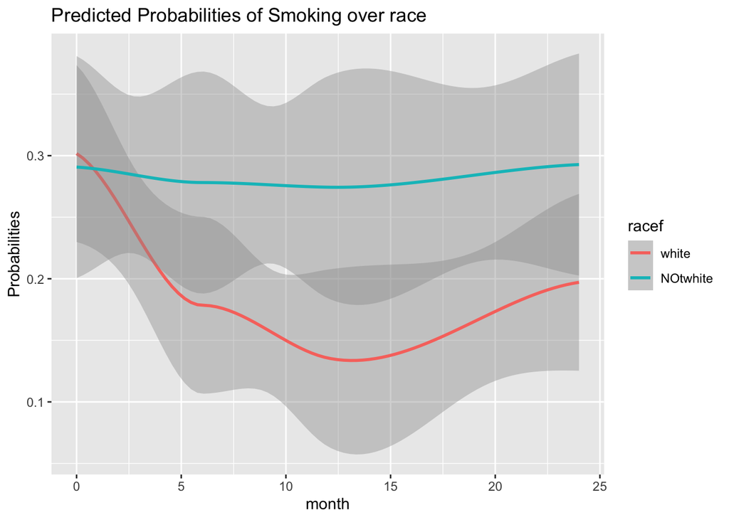

```r
#Create a factor variable for tx
m1_pred$racef <- factor(m1_pred$racew, levels=c(0,1), labels=c("white","NOtwhite"))

library(ggplot2)
#Plot predicted probabilities by treatment group over time using SWEEK
#notice how when we are using the inverse of logit, we DO not get a straight line for SWEEK
p2a = ggplot(m1_pred, aes(x=month,y=prob,group=racef))
p2a + geom_smooth(aes(color=racef)) +
  labs(title="Predicted Probabilities of Smoking over race", y="Probabilities")
```

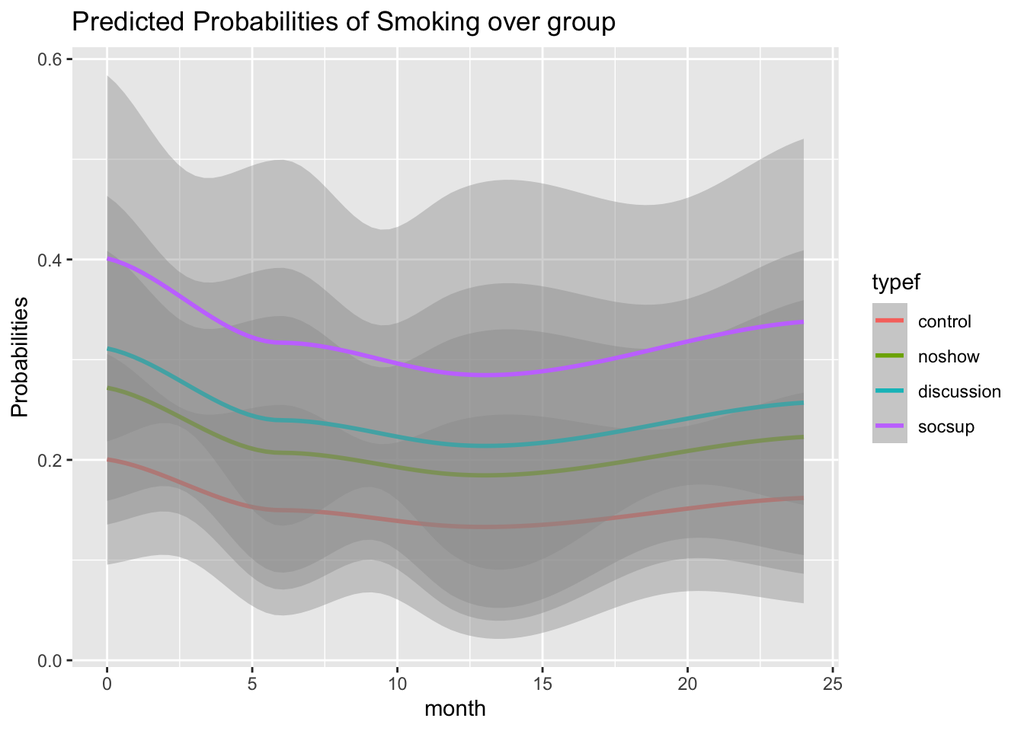

```r
#2e b
m1_pred$typef <- factor(m1_pred$type, levels=c(1,2,3,4), labels=c("control","noshow","discussion","socsup"))

p2b = ggplot(m1_pred, aes(x=month,y=prob,group=typef))
p2b + geom_smooth(aes(color=typef)) +
  labs(title="Predicted Probabilities of Smoking over group", y="Probabilities")
```

From plots; The control group has outcome, since the probability is the lowest.

And the socsup is the highest one, next is the discussion one.

```r
#2f
m1.ind <- geeglm(quit ~ racew*month + racew*monthsquared + noshow*month + noshow*monthsquared + discussion*month +discussion*monthsquared + socsup*month + socsup*monthsquared, data=df, family=binomial(link="logit"),
                 id=id, corstr = "independence", std.err="san.se")

m1.exch <- geeglm(quit ~ racew*month + racew*monthsquared + noshow*month + noshow*monthsquared + discussion*month +discussion*monthsquared + socsup*month + socsup*monthsquared, data=df, family=binomial(link="logit"),
                 id=id, corstr = "exchangeable", std.err="san.se")
m1.ar1 <- geeglm(quit ~ racew*month + racew*monthsquared + noshow*month + noshow*monthsquared + discussion*month +discussion*monthsquared + socsup*month + socsup*monthsquared, data=df, family=binomial(link="logit"),
                 id=id, corstr = "ar1", std.err="san.se")

zcor<-genZcor(clusz = table(df$id), waves = df$occasion + 1, corstrv = 4)
zcor.toep<-matrix(NA, nrow(zcor),3)
zcor.toep[,1]<-apply(zcor[,c(1,4,6)],1,sum)
zcor.toep[,2]<-apply(zcor[,c(2,5)],1,sum)
zcor.toep[,3]<-zcor[,3]
#head(zcor.toep)

m1.toep <- geeglm(quit ~ racew*month + racew*monthsquared + noshow*month + noshow*monthsquared + discussion*month +discussion*monthsquared + socsup*month + socsup*monthsquared, data=df, family=binomial(link="logit"),
                 id=id, corstr = "userdefined", zcor = zcor.toep, std.err="san.se")
m1.un <- geeglm(quit ~ racew*month + racew*monthsquared + noshow*month + noshow*monthsquared + discussion*month +discussion*monthsquared + socsup*month + socsup*monthsquared, data=df, family=binomial(link="logit"),
                 id=id, corstr = "unstructured", std.err="san.se")

QIC(m1.ind)
```

```
##       QIC      QICu Quasi Lik       CIC    params      QICC
##    1796.9    1792.1    -881.1      17.4      15.0    1797.2
```

```r
QIC(m1.exch)
```

```
##       QIC      QICu Quasi Lik       CIC    params      QICC
##    1793.9    1792.4    -881.2      15.7      15.0    1794.2
```

```r
QIC(m1.ar1)
```

```
##       QIC      QICu Quasi Lik       CIC    params      QICC
##    1792.7    1792.9    -881.4      14.9      15.0    1793.0
```

```r
QIC(m1.toep)
```

```
##       QIC      QICu Quasi Lik       CIC    params      QICC
##      1792      1792      -881        15        15      1793
```

```r
QIC(m1.un)
```

```
##       QIC      QICu Quasi Lik       CIC    params      QICC
##    1793.4    1792.6    -881.3      15.4      15.0    1794.0
```

QIC(m1.toep) = 1792 is the samllest, so choose the userdefined model.

```r
summary(m1.toep)
```

```
##
## Call:
## geeglm(formula = quit ~ racew * month + racew * monthsquared +
##     noshow * month + noshow * monthsquared + discussion * month +
##     discussion * monthsquared + socsup * month + socsup * monthsquared,
##     family = binomial(link = "logit"), data = df, id = id, zcor = zcor.toep,
##     corstr = "userdefined", std.err = "san.se")
##
##  Coefficients:
##                          Estimate   Std.err  Wald Pr(>|W|)
## (Intercept)             -1.676977  0.273465 37.61  8.7e-10 ***
## racew                   -0.003872  0.249585  0.00   0.9876
## month                   -0.079121  0.046122  2.94   0.0863 .
## monthsquared             0.003372  0.001699  3.94   0.0471 *
## noshow                   0.674218  0.309729  4.74   0.0295 *
## discussion               0.961570  0.352319  7.45   0.0063 **
## socsup                   1.561164  0.328705 22.56  2.0e-06 ***
## racew:month              0.102338  0.045825  4.99   0.0255 *
## racew:monthsquared      -0.003250  0.001734  3.51   0.0609 .
## month:noshow            -0.032390  0.054838  0.35   0.5548
## monthsquared:noshow      0.000214  0.002048  0.01   0.9169
## month:discussion        -0.095116  0.067386  1.99   0.1581
## monthsquared:discussion  0.002996  0.002540  1.39   0.2381
## month:socsup            -0.126091  0.061312  4.23   0.0397 *
## monthsquared:socsup      0.003496  0.002305  2.30   0.1294
## ---
## Signif. codes:  0 '***' 0.001 '**' 0.01 '*' 0.05 '.' 0.1 ' ' 1
##
## Correlation structure = userdefined
## Estimated Scale Parameters:
##
##             Estimate Std.err
## (Intercept)    0.996  0.0944
##   Link = identity
##
## Estimated Correlation Parameters:
##         Estimate Std.err
## alpha:1    0.409  0.0574
## alpha:2    0.306  0.0553
## alpha:3    0.251  0.0618
## Number of clusters:   489  Maximum cluster size: 4
```

We can see the within-subject association alphas are 0.409, 0.306, 0.251.

OR(Yij, Yik) = exp(alpha) = exp(0.409, 0.306, 0.251.)

```r
#2gi
#from f the final model is:
m1.toep <- geeglm(quit ~ racew*month + racew*monthsquared + noshow*month + noshow*monthsquared + discussion*month +discussion*monthsquared + socsup*month + socsup*monthsquared, data=df, family=binomial(link="logit"),
                 id=id, corstr = "userdefined", zcor = zcor.toep, std.err="san.se")

m1.toep_reduced <- geeglm(quit ~ racew+month + racew+monthsquared + noshow*month + noshow*monthsquared + discussion*month +discussion*monthsquared + socsup*month + socsup*monthsquared, data=df, family=binomial(link="logit"),
                 id=id, corstr = "userdefined", zcor = zcor.toep,std.err="san.se")
summary(m1.toep_reduced)
```

```
##
## Call:
## geeglm(formula = quit ~ racew + month + racew + monthsquared +
##     noshow * month + noshow * monthsquared + discussion * month +
##     discussion * monthsquared + socsup * month + socsup * monthsquared,
##     family = binomial(link = "logit"), data = df, id = id, zcor = zcor.toep,
##     corstr = "userdefined", std.err = "san.se")
##
##  Coefficients:
##                          Estimate   Std.err  Wald Pr(>|W|)
## (Intercept)             -1.78e+00  2.72e-01 42.88  5.8e-11 ***
## racew                    3.55e-01  1.99e-01  3.17   0.0751 .
## month                   -4.34e-02  4.29e-02  1.02   0.3116
## monthsquared             2.23e-03  1.59e-03  1.96   0.1617
## noshow                   6.35e-01  3.10e-01  4.21   0.0402 *
## discussion               1.04e+00  3.53e-01  8.73   0.0031 **
## socsup                   1.61e+00  3.29e-01 23.98  9.7e-07 ***
## month:noshow            -2.75e-02  5.41e-02  0.26   0.6110
## monthsquared:noshow      5.48e-05  2.01e-03  0.00   0.9783
## month:discussion        -1.24e-01  6.68e-02  3.44   0.0637 .
## monthsquared:discussion  3.92e-03  2.53e-03  2.40   0.1214
## month:socsup            -1.45e-01  6.02e-02  5.81   0.0159 *
## monthsquared:socsup      4.11e-03  2.28e-03  3.25   0.0714 .
## ---
## Signif. codes:  0 '***' 0.001 '**' 0.01 '*' 0.05 '.' 0.1 ' ' 1
##
## Correlation structure = userdefined
## Estimated Scale Parameters:
##
##             Estimate Std.err
## (Intercept)    0.989   0.083
##   Link = identity
##
## Estimated Correlation Parameters:
##         Estimate Std.err
## alpha:1    0.408  0.0538
## alpha:2    0.305  0.0532
## alpha:3    0.247  0.0605
## Number of clusters:   489  Maximum cluster size: 4
```

```r
anova(m1.toep,m1.toep_reduced)
```

```
## Analysis of 'Wald statistic' Table
##
## Model 1 quit ~ racew * month + racew * monthsquared + noshow * month + noshow * monthsquared + discussion * month + discussion * monthsquared + socsup * month + socsup * monthsquared
## Model 2 quit ~ racew + month + racew + monthsquared + noshow * month + noshow * monthsquared + discussion * month + discussion * monthsquared + socsup * month + socsup * monthsquared
##   Df   X2 P(>|Chi|)
## 1  2 5.96     0.051 .
## ---
## Signif. codes:  0 '***' 0.001 '**' 0.01 '*' 0.05 '.' 0.1 ' ' 1
```

H0: beta_racew:month= beta_racew:monthsquared = 0

Ha: at least one of them not 0

conclusion and interpretation:

Since the effect size is 489 is not large enough, even the p=0.051

quite small, but we still cannot reject null hypothesis directly.

Might need more test to make sure.

```r
#2gii
#install.packages("aod")
library(aod)
b_hats <- coef(m1.toep)
cov_beta_naive <- m1.toep$geese$vbeta.naiv
wald.test(cov_beta_naive,b_hats, Terms = c(8,9), df=2, verbose=FALSE)
```

```
## Wald test:
## ----------
##
## Chi-squared test:
## X2 = 6.0, df = 2, P(> X2) = 0.049
##
## F test:
## W = 3.0, df1 = 2, df2 = 2, P(> W) = 0.25
```